# PBC attained-age landmark sensitivity analysis

```r
knitr::opts_chunk$set(echo = TRUE, message = FALSE, warning = FALSE,
                      fig.align = "center")
library(here)
devtools::load_all(here::here(), quiet = TRUE)

prediction_window <- 5
dense_age_landmarks <- seq(42, 56, by = 2)
cause_labels <- c("Transplant", "Death")
n_boot <- getOption("dense_age.n_boot", 200L)
bootstrap_seed <- 20260922L
stopifnot(length(n_boot) == 1L, is.finite(n_boot),
          n_boot >= 2L, n_boot == as.integer(n_boot))
n_boot <- as.integer(n_boot)
```

# Purpose

I kept the original time-scale comparison unchanged. This separate analysis tests whether a more closely spaced attained-age grid identifies landmark main effects, how its hazard ratios compare with separate landmark fits, and how often its predictions survive subject-level resampling. The candidate grid is a sensitivity analysis, not a replacement for the entry-age-quartile analysis.

```r
pbc_long <- get_pbc_long()
entry_ages <- unique(pbc_long[c("id", "age")])$age
current_age_landmarks <- round(
  unname(quantile(entry_ages, c(0.25, 0.50, 0.75), type = 8)), 1
)

pbc_age <- transform(
  pbc_long,
  log_bili_z = (log(bili) - mean(log(pbc_long$bili))) /
    sd(log(pbc_long$bili)),
  albumin_z = (albumin - mean(pbc_long$albumin)) / sd(pbc_long$albumin),
  entry_age = age,
  exit_age = age + time,
  visit_age = age + tstart
)

stopifnot(
  !anyDuplicated(unique(pbc_age[c("id", "entry_age")])$id),
  all(is.finite(pbc_age$log_bili_z)),
  all(is.finite(pbc_age$albumin_z)),
  all(diff(current_age_landmarks) > prediction_window),
  all(diff(dense_age_landmarks) < prediction_window)
)
```

# Why the current age grid cannot estimate landmark main effects

I plotted the original landmark windows to make the lack of overlap visible. Each event risk set lies within one window. An LM main effect is therefore constant within that risk set and cancels from the Cox partial likelihood. The model still contains bilirubin-by-LM and albumin-by-LM interactions; it does not contain an estimable LM main effect on this grid.

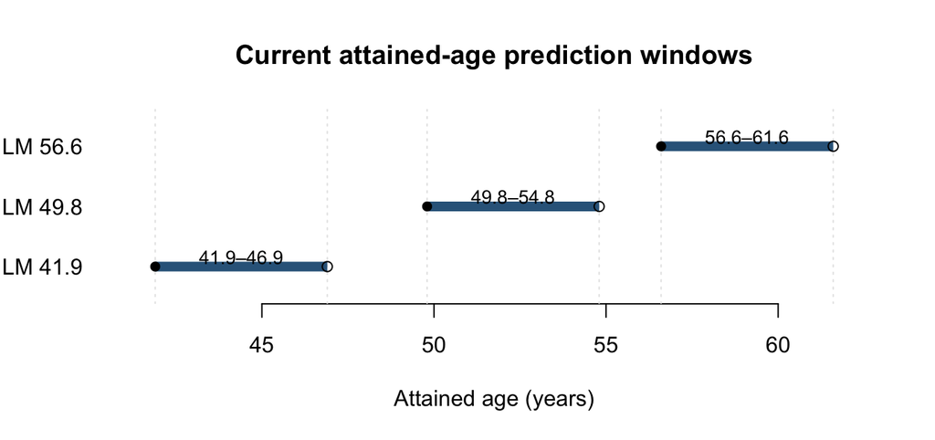

```r
draw_current_windows <- function() {
  window_ends <- current_age_landmarks + prediction_window
  plot(NA, xlim = range(c(current_age_landmarks, window_ends)) + c(-0.5, 0.5),
       ylim = c(0.5, length(current_age_landmarks) + 0.5),
       yaxt = "n", xlab = "Attained age (years)", ylab = "",
       main = "Current attained-age prediction windows", bty = "n")
  axis(2, at = seq_along(current_age_landmarks),
       labels = paste0("LM ", format(current_age_landmarks, nsmall = 1)),
       las = 1, tick = FALSE)
  abline(v = c(current_age_landmarks, window_ends), col = "grey90", lty = 3)
  segments(current_age_landmarks, seq_along(current_age_landmarks),
           window_ends, seq_along(current_age_landmarks),
           lwd = 7, col = "#32658A", lend = "butt")
  points(current_age_landmarks, seq_along(current_age_landmarks), pch = 16)
  points(window_ends, seq_along(current_age_landmarks), pch = 1)
  text((current_age_landmarks + window_ends) / 2,
       seq_along(current_age_landmarks) + 0.16,
       labels = sprintf("%.1f–%.1f", current_age_landmarks, window_ends),
       cex = 0.85)
}

draw_current_windows()
```

```r
pdf(here::here("analysis", "current_age_windows.pdf"),
    width = 7, height = 3.3)
draw_current_windows()
dev.off()
```

```r
current_stack <- stack_data(
  pbc_age, list(time = "exit_age", status = "status"),
  lms = current_age_landmarks, w = prediction_window,
  covs = list(fixed = c("male", "stage", "trt"),
              varying = c("log_bili_z", "albumin_z")),
  format = "long", id = "id", rtime = "visit_age",
  entry = "entry_age", entry_mode = "strict"
)

risk_set_lm_counts <- function(stack) {
  event_times <- sort(unique(stack$data$exit_age[stack$data$status > 0]))
  vapply(event_times, function(event_age) {
    at_risk <- stack$data$LM < event_age & stack$data$exit_age >= event_age
    length(unique(stack$data$LM[at_risk]))
  }, integer(1))
}

current_lm_counts <- risk_set_lm_counts(current_stack)
stopifnot(length(current_lm_counts) > 0L,
          all(current_lm_counts == 1L))
knitr::kable(data.frame(
  grid = "Current entry-age quartiles",
  event_times = length(current_lm_counts),
  event_times_with_multiple_LMs = sum(current_lm_counts > 1L)
))
```

| grid | event_times | event_times_with_multiple_LMs |
| --- | --- | --- |
| Current entry-age quartiles | 39 | 0 |

# Dense-grid risk sets

I used the same strict-entry rule, event coding, prediction window, and laboratory transformations as the primary attained-age analysis. I checked the number of people and both event types in every window before fitting or resampling. These counts are stacked-window counts: an event can contribute to more than one overlapping window.

```r
dense_stack_raw <- stack_data(
  pbc_age, list(time = "exit_age", status = "status"),
  lms = dense_age_landmarks, w = prediction_window,
  covs = list(fixed = c("male", "stage", "trt"),
              varying = c("log_bili_z", "albumin_z")),
  format = "long", id = "id", rtime = "visit_age",
  entry = "entry_age", entry_mode = "strict"
)

dense_risk_sets <- do.call(rbind, lapply(dense_age_landmarks, function(age) {
  rows <- dense_stack_raw$data[dense_stack_raw$data$LM == age, , drop = FALSE]
  data.frame(
    landmark = age,
    window_end = age + prediction_window,
    subjects = length(unique(rows$id)),
    deaths = sum(rows$status == 2L),
    transplants = sum(rows$status == 1L),
    censored = sum(rows$status == 0L)
  )
}))

dense_lm_counts <- risk_set_lm_counts(dense_stack_raw)
stopifnot(
  identical(dense_stack_raw$entry_mode, "strict"),
  all(dense_stack_raw$data$entry_age <= dense_stack_raw$data$LM),
  all(dense_stack_raw$data$LM < dense_stack_raw$data$exit_age),
  !anyDuplicated(dense_stack_raw$data[c("id", "LM")]),
  all(dense_risk_sets$subjects > 0L),
  all(dense_risk_sets$subjects ==
        dense_risk_sets$deaths + dense_risk_sets$transplants +
        dense_risk_sets$censored),
  any(dense_lm_counts > 1L)
)

knitr::kable(dense_risk_sets,
             caption = "Strict-entry risk sets on the candidate age grid")
```

Strict-entry risk sets on the candidate age grid

| landmark | window_end | subjects | deaths | transplants | censored |
| --- | --- | --- | --- | --- | --- |
| 42 | 47 | 37 | 7 | 7 | 23 |
| 44 | 49 | 34 | 6 | 2 | 26 |
| 46 | 51 | 47 | 9 | 3 | 35 |
| 48 | 53 | 52 | 11 | 2 | 39 |
| 50 | 55 | 54 | 8 | 2 | 44 |
| 52 | 57 | 52 | 14 | 1 | 37 |
| 54 | 59 | 61 | 20 | 0 | 41 |
| 56 | 61 | 58 | 19 | 1 | 38 |

```r
knitr::kable(data.frame(
  grid = "Candidate two-year grid",
  event_times = length(dense_lm_counts),
  event_times_with_multiple_LMs = sum(dense_lm_counts > 1L),
  maximum_LMs_in_one_risk_set = max(dense_lm_counts)
))
```

| grid | event_times | event_times_with_multiple_LMs | maximum_LMs_in_one_risk_set |
| --- | --- | --- | --- |
| Candidate two-year grid | 67 | 54 | 3 |

The dense windows overlap, and the observed event risk sets contain multiple landmark values. This removes the exact non-identifiability of LM main effects seen on the original grid. It does not by itself establish that the competing-risk fit or its bootstrap is stable: the event-count table includes windows with very few transplants.

# Candidate supermodel fit

I used a centered quadratic landmark basis for both main effects and the two laboratory interactions. The other predictors and the cause-specific CSC fit match the primary attained-age specification.

```r
dense_center <- mean(dense_age_landmarks)
dense_half_range <- diff(range(dense_age_landmarks)) / 2
dense_basis <- list(
  function(age) (age - dense_center) / dense_half_range,
  function(age) ((age - dense_center) / dense_half_range)^2
)
dense_stack <- add_interactions(
  dense_stack_raw,
  lm_covs = c("log_bili_z", "albumin_z"),
  func_covars = dense_basis,
  func_lms = dense_basis
)
stopifnot(all(c("LM1", "LM2", "log_bili_z_LM1", "log_bili_z_LM2",
                "albumin_z_LM1", "albumin_z_LM2") %in%
              names(dense_stack$data)))

dense_formula <- Hist(exit_age, status, LM) ~
  male + stage + trt +
  log_bili_z + log_bili_z_LM1 + log_bili_z_LM2 +
  albumin_z + albumin_z_LM1 + albumin_z_LM2 +
  LM1 + LM2 + cluster(id)

capture_conditions <- function(expression) {
  warnings <- character()
  value <- withCallingHandlers(
    tryCatch(eval.parent(substitute(expression)), error = function(error) error),
    warning = function(warning) {
      warnings <<- c(warnings, conditionMessage(warning))
      invokeRestart("muffleWarning")
    }
  )
  list(value = value, warnings = unique(warnings))
}

dense_fit_record <- capture_conditions(dynamic_lm(
  dense_stack, dense_formula, type = "CSC", method = "breslow", x = TRUE
))

fit_status <- data.frame(
  error = if (inherits(dense_fit_record$value, "error")) {
    conditionMessage(dense_fit_record$value)
  } else "",
  warnings = paste(dense_fit_record$warnings, collapse = " | ")
)
knitr::kable(fit_status)
```

| error | warnings |
| --- | --- |

```r
if (!inherits(dense_fit_record$value, "error")) {
  dense_fit <- dense_fit_record$value
  dense_lm_inference <- do.call(rbind, lapply(seq_along(
    dense_fit$model$causes
  ), function(index) {
    fit <- dense_fit$model$models[[index]]
    terms <- c("LM1", "LM2")
    data.frame(
      cause = cause_labels[as.integer(dense_fit$model$causes[index])],
      term = terms,
      coefficient = unname(coef(fit)[terms]),
      robust_se = unname(sqrt(diag(vcov(fit)))[terms])
    )
  }))
  stopifnot(all(is.finite(dense_lm_inference$coefficient)),
            all(is.finite(dense_lm_inference$robust_se)))
  knitr::kable(dense_lm_inference, digits = 3)
}
```

| cause | term | coefficient | robust_se |
| --- | --- | --- | --- |
| Transplant | LM1 | -0.083 | 2.311 |
| Transplant | LM2 | 3.894 | 1.726 |
| Death | LM1 | -2.145 | 0.541 |
| Death | LM2 | 0.550 | 0.490 |

## Linear landmark sensitivity

I fitted a second pooled model on the same stack and with the same predictors, keeping only the centered linear landmark main effect and linear laboratory interactions. The quadratic model above remains the reference analysis.

```r
linear_basis <- dense_basis[1L]
linear_stack <- add_interactions(
  dense_stack_raw,
  lm_covs = c("log_bili_z", "albumin_z"),
  func_covars = linear_basis,
  func_lms = linear_basis
)
stopifnot(
  all(c("LM1", "log_bili_z_LM1", "albumin_z_LM1") %in%
        names(linear_stack$data)),
  !any(c("LM2", "log_bili_z_LM2", "albumin_z_LM2") %in%
         names(linear_stack$data)),
  identical(dense_stack_raw$data[c("id", "LM")],
            linear_stack$data[c("id", "LM")])
)

linear_formula <- Hist(exit_age, status, LM) ~
  male + stage + trt +
  log_bili_z + log_bili_z_LM1 +
  albumin_z + albumin_z_LM1 + LM1 + cluster(id)
linear_fit_record <- capture_conditions(dynamic_lm(
  linear_stack, linear_formula, type = "CSC", method = "breslow", x = TRUE
))
linear_fit_status <- data.frame(
  error = if (inherits(linear_fit_record$value, "error")) {
    conditionMessage(linear_fit_record$value)
  } else "",
  warnings = paste(linear_fit_record$warnings, collapse = " | ")
)
knitr::kable(linear_fit_status)
```

| error | warnings |
| --- | --- |

```r
stopifnot(!inherits(linear_fit_record$value, "error"))
linear_fit <- linear_fit_record$value
linear_death_fit <- linear_fit$model$models[[
  match(2L, linear_fit$model$causes)
]]
linear_robust_se <- sqrt(diag(vcov(linear_death_fit)))
stopifnot(
  all(is.finite(coef(linear_death_fit))),
  all(is.finite(linear_robust_se)),
  max(abs(linear_robust_se -
            summary(linear_death_fit)$coefficients[, "robust se"])) < 1e-12
)
```

# Separate landmark fits as a sparsity check

I also tried the unchanged, one-model-per-landmark specification. I recorded all fit warnings and errors rather than modifying a sparse fit to make it converge. The pooled supermodel can be estimable even when a separate competing-risk fit at one age is not.

```r
dense_disjoint_formula <- Hist(exit_age, status, LM) ~
  male + stage + trt + log_bili_z + albumin_z + cluster(id)

dense_disjoint_records <- setNames(lapply(
  dense_age_landmarks, function(age) {
    one_landmark <- dense_stack_raw
    one_landmark$data <- dense_stack_raw$data[
      dense_stack_raw$data$LM == age, , drop = FALSE
    ]
    one_landmark$end_time <- age
    capture_conditions(dynamic_lm(
      one_landmark, dense_disjoint_formula,
      type = "CSC", method = "breslow", x = TRUE
    ))
  }), as.character(dense_age_landmarks)
)
dense_disjoint_conditions <- do.call(rbind, lapply(
  dense_age_landmarks, function(age) {
    fit_record <- dense_disjoint_records[[as.character(age)]]
    data.frame(landmark = age,
               fit_error = if (inherits(fit_record$value, "error")) {
                 conditionMessage(fit_record$value)
               } else "",
               warnings = paste(fit_record$warnings, collapse = " | "))
  }))

stopifnot(nrow(dense_disjoint_conditions) == length(dense_age_landmarks))
knitr::kable(dense_disjoint_conditions)
```

| landmark | fit_error | warnings |
| --- | --- | --- |
| 42 |  |  |
| 44 |  | Loglik converged before variable 1 ; beta may be infinite. |
| 46 |  | Loglik converged before variable 1 ; beta may be infinite. |
| 48 |  | Loglik converged before variable 1,3 ; beta may be infinite. |
| 50 |  | Ran out of iterations and did not converge \| Loglik converged before variable 1 ; beta may be infinite. |
| 52 |  | Ran out of iterations and did not converge |
| 54 | arguments imply differing number of rows: 61, 0 | Object ‘Hist’ does not have this element: event. Returning NULL. |
| 56 |  | Ran out of iterations and did not converge |

I traced each flagged fit back to its two cause-specific Cox models. The direct fits use the same counting-process response, predictors, tie method, and subject clustering as the separate CSC fit. I kept the CSC wrapper’s message alongside the cause-specific messages, since a zero-event cause can make the wrapper fail without making `coxph()` itself throw an error.

```r
flagged_ages <- dense_disjoint_conditions$landmark[
  nzchar(dense_disjoint_conditions$fit_error) |
    nzchar(dense_disjoint_conditions$warnings)
]
disjoint_cause_conditions <- do.call(rbind, lapply(flagged_ages, function(age) {
  rows <- dense_stack_raw$data[dense_stack_raw$data$LM == age, , drop = FALSE]
  outer <- dense_disjoint_records[[as.character(age)]]
  direct_records <- lapply(c(1L, 2L), function(cause) {
    formula <- as.formula(paste0(
      "survival::Surv(LM, exit_age, status == ", cause, ") ~ ",
      "male + stage + trt + log_bili_z + albumin_z + cluster(id)"
    ))
    capture_conditions(survival::coxph(
      formula, data = rows, method = "breslow", x = TRUE
    ))
  })
  if (!inherits(outer$value, "error")) {
    direct_warnings <- unique(unlist(lapply(direct_records, `[[`, "warnings")))
    stopifnot(setequal(direct_warnings, outer$warnings))
    for (index in seq_along(direct_records)) {
      direct <- direct_records[[index]]$value
      wrapped <- outer$value$model$models[[
        match(index, outer$value$model$causes)
      ]]
      if (!inherits(direct, "error")) {
        terms <- intersect(names(coef(direct)), names(coef(wrapped)))
        finite <- terms[is.finite(coef(direct)[terms]) &
                          is.finite(coef(wrapped)[terms])]
        if (length(finite)) {
          stopifnot(max(abs(coef(direct)[finite] -
                            coef(wrapped)[finite])) < 1e-8)
        }
      }
    }
  }
  cause_rows <- do.call(rbind, lapply(seq_along(direct_records), function(index) {
    record <- direct_records[[index]]
    data.frame(
      landmark = age,
      source = cause_labels[index],
      events = sum(rows$status == index),
      finite_coefficients = if (inherits(record$value, "error")) NA_integer_ else
        sum(is.finite(coef(record$value))),
      warning = paste(record$warnings, collapse = " | "),
      error = if (inherits(record$value, "error")) {
        conditionMessage(record$value)
      } else "",
      row.names = NULL
    )
  }))
  if (inherits(outer$value, "error")) {
    cause_rows <- rbind(cause_rows, data.frame(
      landmark = age, source = "CSC wrapper", events = NA_integer_,
      finite_coefficients = NA_integer_,
      warning = paste(outer$warnings, collapse = " | "),
      error = conditionMessage(outer$value), row.names = NULL
    ))
  }
  cause_rows
}))
knitr::kable(disjoint_cause_conditions,
             caption = "Exact conditions by cause; the CSC wrapper row is shown when it fails")
```

Exact conditions by cause; the CSC wrapper row is shown when it fails

| landmark | source | events | finite_coefficients | warning | error |
| --- | --- | --- | --- | --- | --- |
| 44 | Transplant | 2 | 5 | Loglik converged before variable 1 ; beta may be infinite. |  |
| 44 | Death | 6 | 5 | Loglik converged before variable 1 ; beta may be infinite. |  |
| 46 | Transplant | 3 | 5 | Loglik converged before variable 1 ; beta may be infinite. |  |
| 46 | Death | 9 | 5 |  |  |
| 48 | Transplant | 2 | 5 | Loglik converged before variable 1,3 ; beta may be infinite. |  |
| 48 | Death | 11 | 5 |  |  |
| 50 | Transplant | 2 | 5 | Ran out of iterations and did not converge |  |
| 50 | Death | 8 | 5 | Loglik converged before variable 1 ; beta may be infinite. |  |
| 52 | Transplant | 1 | 5 | Ran out of iterations and did not converge |  |
| 52 | Death | 14 | 5 |  |  |
| 54 | Transplant | 0 | 0 |  |  |
| 54 | Death | 20 | 5 |  |  |
| 54 | CSC wrapper | NA | NA | Object ‘Hist’ does not have this element: event. Returning NULL. | arguments imply differing number of rows: 61, 0 |
| 56 | Transplant | 1 | 5 | Ran out of iterations and did not converge |  |
| 56 | Death | 19 | 5 |  |  |

# Death-model laboratory hazard ratios

I combined each laboratory main effect with its landmark interactions and used the fitted robust covariance for the supermodel interval. For each separate landmark fit, I used the death-model coefficient and robust standard error. CI-width ratios are on the log-HR scale, as in the primary comparison. An unavailable separate fit remains unavailable in the table and figure.

```r
death_index <- match(2L, dense_fit$model$causes)
stopifnot(length(death_index) == 1L, !is.na(death_index))
dense_death_fit <- dense_fit$model$models[[death_index]]
robust_se <- sqrt(diag(vcov(dense_death_fit)))
summary_se <- summary(dense_death_fit)$coefficients[, "robust se"]
stopifnot(identical(names(robust_se), names(coef(dense_death_fit))),
          max(abs(robust_se - summary_se), na.rm = TRUE) < 1e-12)

critical_value <- qnorm(0.975)
laboratory_terms <- c(log_bili_z = "Log bilirubin (per SD)",
                      albumin_z = "Albumin (per SD)")

supermodel_log_hr <- function(marker, ages) {
  terms <- c(marker, paste0(marker, c("_LM1", "_LM2")))
  design <- cbind(1, dense_basis[[1]](ages), dense_basis[[2]](ages))
  beta <- coef(dense_death_fit)[terms]
  covariance <- vcov(dense_death_fit)[terms, terms, drop = FALSE]
  estimate <- drop(design %*% beta)
  se <- sqrt(rowSums((design %*% covariance) * design))
  stopifnot(all(is.finite(estimate)), all(is.finite(se)))
  data.frame(landmark = ages, estimate = estimate,
             lower = estimate - critical_value * se,
             upper = estimate + critical_value * se)
}

linear_log_hr <- function(marker, ages) {
  terms <- c(marker, paste0(marker, "_LM1"))
  design <- cbind(1, linear_basis[[1L]](ages))
  beta <- coef(linear_death_fit)[terms]
  covariance <- vcov(linear_death_fit)[terms, terms, drop = FALSE]
  estimate <- drop(design %*% beta)
  se <- sqrt(rowSums((design %*% covariance) * design))
  stopifnot(all(is.finite(estimate)), all(is.finite(se)))
  data.frame(landmark = ages, estimate = estimate,
             lower = estimate - critical_value * se,
             upper = estimate + critical_value * se)
}

disjoint_log_hr <- function(age, marker) {
  record <- dense_disjoint_records[[as.character(age)]]
  if (inherits(record$value, "error")) {
    return(c(estimate = NA_real_, lower = NA_real_, upper = NA_real_))
  }
  cause_index <- match(2L, record$value$model$causes)
  stopifnot(!is.na(cause_index))
  fit <- record$value$model$models[[cause_index]]
  estimate <- coef(fit)[marker]
  se <- sqrt(diag(vcov(fit)))[marker]
  if (!is.finite(estimate) || !is.finite(se)) {
    return(c(estimate = NA_real_, lower = NA_real_, upper = NA_real_))
  }
  c(estimate = estimate,
    lower = estimate - critical_value * se,
    upper = estimate + critical_value * se)
}

laboratory_comparison <- do.call(rbind, lapply(names(laboratory_terms),
  function(marker) {
    super <- supermodel_log_hr(marker, dense_age_landmarks)
    linear <- linear_log_hr(marker, dense_age_landmarks)
    separate <- t(vapply(dense_age_landmarks,
      function(age) disjoint_log_hr(age, marker),
      c(estimate = 0, lower = 0, upper = 0)))
    conditions <- dense_disjoint_conditions[
      match(dense_age_landmarks, dense_disjoint_conditions$landmark), ]
    data.frame(
      covariate = unname(laboratory_terms[marker]),
      landmark = dense_age_landmarks,
      super_estimate = super$estimate,
      super_lower = super$lower,
      super_upper = super$upper,
      linear_estimate = linear$estimate,
      linear_lower = linear$lower,
      linear_upper = linear$upper,
      disjoint_estimate = separate[, "estimate"],
      disjoint_lower = separate[, "lower"],
      disjoint_upper = separate[, "upper"],
      CI_width_ratio_log_scale =
        (separate[, "upper"] - separate[, "lower"]) /
        (super$upper - super$lower),
      fit_flag = ifelse(nzchar(conditions$fit_error), "failed",
                        ifelse(nzchar(conditions$warnings), "warning", "ok")),
      row.names = NULL
    )
  }
))

format_hr <- function(estimate, lower, upper) {
  ifelse(is.finite(estimate) & is.finite(lower) & is.finite(upper),
         sprintf("%.3f (%.3f, %.3f)",
                 exp(estimate), exp(lower), exp(upper)), "—")
}
laboratory_display <- data.frame(
  covariate = laboratory_comparison$covariate,
  landmark = laboratory_comparison$landmark,
  supermodel_HR_95_CI = with(laboratory_comparison,
    format_hr(super_estimate, super_lower, super_upper)),
  linear_HR_95_CI = with(laboratory_comparison,
    format_hr(linear_estimate, linear_lower, linear_upper)),
  disjoint_HR_95_CI = with(laboratory_comparison,
    format_hr(disjoint_estimate, disjoint_lower, disjoint_upper)),
  disjoint_to_supermodel_CI_width =
    laboratory_comparison$CI_width_ratio_log_scale,
  fit_flag = laboratory_comparison$fit_flag
)
stopifnot(nrow(laboratory_display) ==
            length(dense_age_landmarks) * length(laboratory_terms))
knitr::kable(laboratory_display, digits = 2)
```

| covariate | landmark | supermodel_HR_95_CI | linear_HR_95_CI | disjoint_HR_95_CI | disjoint_to_supermodel_CI_width | fit_flag |
| --- | --- | --- | --- | --- | --- | --- |
| Log bilirubin (per SD) | 42 | 1.414 (0.636, 3.143) | 2.307 (1.240, 4.293) | 4.618 (1.728, 12.340) | 1.23 | ok |
| Log bilirubin (per SD) | 44 | 2.401 (1.404, 4.104) | 2.596 (1.561, 4.319) | 2.588 (0.923, 7.255) | 1.92 | warning |
| Log bilirubin (per SD) | 46 | 3.585 (2.286, 5.622) | 2.921 (1.940, 4.399) | 45.055 (13.520, 150.148) | 2.68 | warning |
| Log bilirubin (per SD) | 48 | 4.711 (2.994, 7.412) | 3.287 (2.355, 4.589) | 2.543 (0.920, 7.032) | 2.24 | warning |
| Log bilirubin (per SD) | 50 | 5.445 (3.491, 8.494) | 3.699 (2.740, 4.994) | 6.003 (3.371, 10.691) | 1.30 | warning |
| Log bilirubin (per SD) | 52 | 5.537 (3.728, 8.225) | 4.162 (3.014, 5.747) | 31.663 (9.117, 109.967) | 3.15 | warning |
| Log bilirubin (per SD) | 54 | 4.954 (3.422, 7.172) | 4.683 (3.166, 6.928) | — | NA | failed |
| Log bilirubin (per SD) | 56 | 3.899 (2.318, 6.558) | 5.270 (3.237, 8.580) | 3.481 (1.911, 6.337) | 1.15 | warning |
| Albumin (per SD) | 42 | 0.442 (0.163, 1.200) | 0.429 (0.235, 0.784) | 0.466 (0.194, 1.122) | 0.88 | ok |
| Albumin (per SD) | 44 | 0.461 (0.258, 0.823) | 0.464 (0.283, 0.758) | 0.234 (0.033, 1.639) | 3.36 | warning |
| Albumin (per SD) | 46 | 0.485 (0.327, 0.720) | 0.500 (0.339, 0.738) | 0.545 (0.237, 1.251) | 2.10 | warning |
| Albumin (per SD) | 48 | 0.514 (0.346, 0.764) | 0.540 (0.401, 0.729) | 0.419 (0.165, 1.062) | 2.35 | warning |
| Albumin (per SD) | 50 | 0.549 (0.368, 0.819) | 0.583 (0.458, 0.742) | 0.688 (0.213, 2.221) | 2.93 | warning |
| Albumin (per SD) | 52 | 0.591 (0.422, 0.827) | 0.630 (0.496, 0.799) | 0.247 (0.125, 0.488) | 2.02 | warning |
| Albumin (per SD) | 54 | 0.641 (0.477, 0.861) | 0.680 (0.508, 0.910) | — | NA | failed |
| Albumin (per SD) | 56 | 0.701 (0.413, 1.189) | 0.734 (0.502, 1.072) | 0.711 (0.325, 1.553) | 1.48 | warning |

```r
finite_comparisons <- laboratory_comparison[
  is.finite(laboratory_comparison$disjoint_estimate), ]
different_at_each_landmark <- all(abs(
  finite_comparisons$super_estimate - finite_comparisons$disjoint_estimate
) > 1e-8)
cat(if (different_at_each_landmark) {
  "The quadratic supermodel now smooths: its laboratory HRs do not reproduce the separate-model HRs at any estimable landmark."
} else {
  "The quadratic supermodel differs from the separate models at some, but not all, estimable landmarks."
})
```

```
## The quadratic supermodel now smooths: its laboratory HRs do not reproduce the separate-model HRs at any estimable landmark.
```

```r
condition_rows <- dense_disjoint_conditions[
  nzchar(dense_disjoint_conditions$fit_error) |
    nzchar(dense_disjoint_conditions$warnings), ]
condition_text <- vapply(seq_len(nrow(condition_rows)), function(index) {
  row <- condition_rows[index, ]
  paste0("age ", row$landmark, ": ",
         paste(c(row$fit_error, row$warnings)[
           nzchar(c(row$fit_error, row$warnings))], collapse = " | "))
}, character(1))
hr_figure_caption <- paste(
  "Death-model HR per SD of the laboratory measure; solid line and grey band: quadratic supermodel and robust 95% CI; dashed line: linear supermodel; point bars: disjoint robust 95% CIs.",
  "Filled points: unflagged separate fits; open points: warned fits; crosses at the lower axis: failed fits.",
  "Recorded conditions:", paste(condition_text, collapse = "; ")
)
```

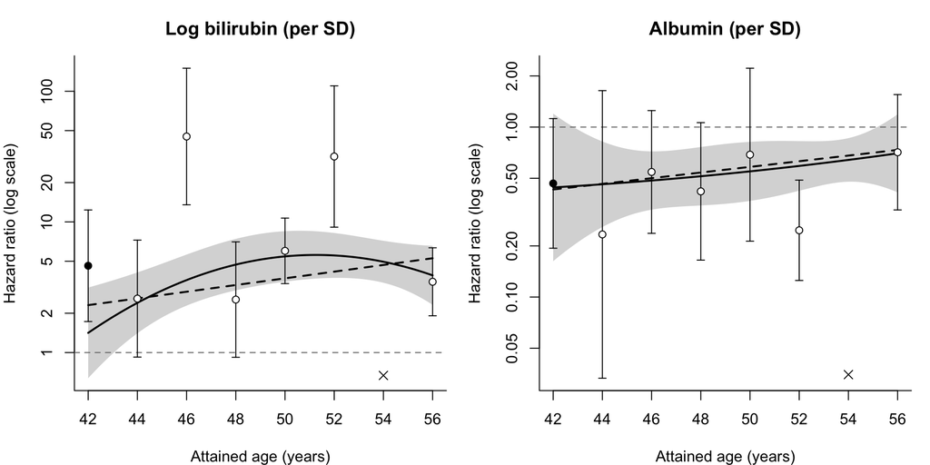

Death-model HR per SD of the laboratory measure; solid line and grey band: quadratic supermodel and robust 95% CI; dashed line: linear supermodel; point bars: disjoint robust 95% CIs. Filled points: unflagged separate fits; open points: warned fits; crosses at the lower axis: failed fits. Recorded conditions: age 44: Loglik converged before variable 1 ; beta may be infinite. ; age 46: Loglik converged before variable 1 ; beta may be infinite. ; age 48: Loglik converged before variable 1,3 ; beta may be infinite. ; age 50: Ran out of iterations and did not converge | Loglik converged before variable 1 ; beta may be infinite. ; age 52: Ran out of iterations and did not converge; age 54: arguments imply differing number of rows: 61, 0 | Object ‘Hist’ does not have this element: event. Returning NULL.; age 56: Ran out of iterations and did not converge

```r
plot_laboratory_hr <- function(marker, label) {
  ages <- seq(min(dense_age_landmarks), max(dense_age_landmarks),
              length.out = 200L)
  curve <- supermodel_log_hr(marker, ages)
  linear_curve <- linear_log_hr(marker, ages)
  rows <- laboratory_comparison[
    laboratory_comparison$covariate == label, ]
  y_values <- exp(c(curve$lower, curve$upper, linear_curve$estimate,
                    rows$disjoint_lower, rows$disjoint_upper, 0))
  y_limits <- range(y_values[is.finite(y_values) & y_values > 0])
  plot(ages, exp(curve$estimate), type = "n", log = "y",
       ylim = y_limits, xlab = "Attained age (years)",
       ylab = "Hazard ratio (log scale)", main = label, bty = "l")
  polygon(c(ages, rev(ages)),
          c(exp(curve$lower), rev(exp(curve$upper))),
          col = "grey85", border = NA)
  abline(h = 1, lty = 2, col = "grey45")
  lines(ages, exp(curve$estimate), lwd = 2)
  lines(ages, exp(linear_curve$estimate), lwd = 2, lty = 2)
  finite <- is.finite(rows$disjoint_estimate) &
    is.finite(rows$disjoint_lower) & is.finite(rows$disjoint_upper)
  arrows(rows$landmark[finite], exp(rows$disjoint_lower[finite]),
         rows$landmark[finite], exp(rows$disjoint_upper[finite]),
         angle = 90, code = 3, length = 0.04)
  points(rows$landmark[finite], exp(rows$disjoint_estimate[finite]),
         pch = ifelse(rows$fit_flag[finite] == "warning", 21, 19),
         bg = "white")
  failed <- rows$fit_flag == "failed" | !finite
  if (any(failed)) {
    points(rows$landmark[failed], y_limits[1] * 1.05, pch = 4, cex = 1.2)
  }
}

old_par <- par(mfrow = c(1, 2), mar = c(4, 4, 3, 1))
for (marker in names(laboratory_terms)) {
  plot_laboratory_hr(marker, unname(laboratory_terms[marker]))
}
```

```r
par(old_par)
```

# Supermodel prediction and bootstrap

I kept the disjoint fit failures above as findings. For prediction I evaluated the pooled supermodel alone. The bootstrap resampled people rather than stacked rows, assigned a new ID to each resampled copy, rebuilt the strict age stack, refitted both cause-specific hazards, and scored the training and original cohorts at each landmark. The grid, window, transformations, and seed were fixed before resampling.

```r
subset_prediction <- function(prediction, age) {
  rows <- prediction$data$LM == age
  if (!any(rows)) stop("No predicted rows at age ", age)
  out <- prediction
  out$data <- prediction$data[rows, , drop = FALSE]
  out$preds <- prediction$preds[rows, , drop = FALSE]
  stopifnot(nrow(out$data) == nrow(out$preds))
  out
}

score_prediction <- function(prediction, age) {
  if (anyNA(prediction$preds$risk)) {
    return(list(AUC = NA_real_, Brier = NA_real_,
                error = "NA predicted risk"))
  }
  record <- capture_conditions(score(
    list(Model = prediction), times = age, metrics = c("auc", "brier"),
    id_col = "id", cause = 2L, summary = FALSE, contrasts = FALSE
  ))
  if (inherits(record$value, "error")) {
    return(list(AUC = NA_real_, Brier = NA_real_,
                error = conditionMessage(record$value)))
  }
  auc <- as.data.frame(record$value$AUC$score)
  brier <- as.data.frame(record$value$Brier$score)
  auc <- auc[as.character(auc$model) == "Model", , drop = FALSE]
  brier <- brier[as.character(brier$model) == "Model", , drop = FALSE]
  if (nrow(auc) != 1L || nrow(brier) != 1L ||
      !is.finite(auc$AUC) || !is.finite(brier$Brier)) {
    return(list(AUC = NA_real_, Brier = NA_real_,
                error = "non-finite or missing score"))
  }
  list(AUC = auc$AUC, Brier = brier$Brier, error = "")
}

resample_people <- function(data, sampled_ids) {
  copies <- lapply(seq_along(sampled_ids), function(index) {
    rows <- data[data$id == sampled_ids[index], , drop = FALSE]
    stopifnot(nrow(rows) > 0L)
    rows$id <- index
    rows
  })
  sample_data <- do.call(rbind, copies)
  rownames(sample_data) <- NULL
  stopifnot(length(unique(sample_data$id)) == length(sampled_ids))
  sample_data
}

build_dense_stack <- function(data) {
  raw <- stack_data(
    data, list(time = "exit_age", status = "status"),
    lms = dense_age_landmarks, w = prediction_window,
    covs = list(fixed = c("male", "stage", "trt"),
                varying = c("log_bili_z", "albumin_z")),
    format = "long", id = "id", rtime = "visit_age",
    entry = "entry_age", entry_mode = "strict"
  )
  stopifnot(!anyDuplicated(raw$data[c("id", "LM")]),
            all(raw$data$entry_age <= raw$data$LM))
  model <- add_interactions(
    raw, lm_covs = c("log_bili_z", "albumin_z"),
    func_covars = dense_basis, func_lms = dense_basis
  )
  stopifnot(!anyDuplicated(model$data[c("id", "LM")]),
            identical(raw$data[c("id", "LM")], model$data[c("id", "LM")]))
  model
}

empty_bootstrap_rows <- function(replicate) {
  data.frame(
    replicate = replicate, landmark = dense_age_landmarks,
    zero_transplants = NA, zero_deaths = NA,
    transplant_fit_error = "", transplant_fit_warning = "",
    death_fit_error = "", death_fit_warning = "",
    nonfinite_cause = "", pooled_fit_warning = "",
    train_AUC = NA_real_, test_AUC = NA_real_,
    train_Brier = NA_real_, test_Brier = NA_real_,
    failed_step = "", failure_detail = "", complete = FALSE
  )
}

diagnose_cause <- function(stack, cause) {
  formula <- as.formula(paste0(
    "survival::Surv(LM, exit_age, status == ", cause, ") ~ ",
    "male + stage + trt + log_bili_z + log_bili_z_LM1 + ",
    "log_bili_z_LM2 + albumin_z + albumin_z_LM1 + ",
    "albumin_z_LM2 + LM1 + LM2 + cluster(id)"
  ))
  record <- capture_conditions(survival::coxph(
    formula, data = stack$data, method = "breslow", x = TRUE
  ))
  list(
    error = if (inherits(record$value, "error")) {
      conditionMessage(record$value)
    } else "",
    warning = paste(record$warnings, collapse = " | ")
  )
}

original_prediction_record <- capture_conditions(predict(
  dense_fit, newdata = dense_stack, cause = 2L
))
stopifnot(!inherits(original_prediction_record$value, "error"))
original_prediction <- original_prediction_record$value
apparent_scores <- do.call(rbind, lapply(dense_age_landmarks, function(age) {
  metric <- score_prediction(subset_prediction(original_prediction, age), age)
  data.frame(landmark = age, AUC = metric$AUC, Brier = metric$Brier,
             score_error = metric$error)
}))
stopifnot(all(is.finite(apparent_scores$AUC)),
          all(is.finite(apparent_scores$Brier)),
          !any(nzchar(apparent_scores$score_error)))
knitr::kable(apparent_scores, digits = 4)
```

| landmark | AUC | Brier | score_error |
| --- | --- | --- | --- |
| 42 | 0.7477 | 0.1814 |  |
| 44 | 0.9802 | 0.0800 |  |
| 46 | 0.9128 | 0.1034 |  |
| 48 | 0.8890 | 0.1304 |  |
| 50 | 0.9162 | 0.0936 |  |
| 52 | 0.9848 | 0.0670 |  |
| 54 | 0.8565 | 0.1266 |  |
| 56 | 0.7764 | 0.1799 |  |

```r
set.seed(bootstrap_seed)
original_ids <- unique(pbc_age$id)
bootstrap_samples <- lapply(seq_len(n_boot), function(index) {
  sample(original_ids, length(original_ids), replace = TRUE)
})

run_dense_replicate <- function(index) {
  row <- empty_bootstrap_rows(index)
  sampled <- capture_conditions(resample_people(
    pbc_age, bootstrap_samples[[index]]
  ))
  if (inherits(sampled$value, "error")) {
    row$failed_step <- "resample"
    row$failure_detail <- conditionMessage(sampled$value)
    return(row)
  }
  stack_record <- capture_conditions(build_dense_stack(sampled$value))
  if (inherits(stack_record$value, "error")) {
    row$failed_step <- "stack"
    row$failure_detail <- conditionMessage(stack_record$value)
    return(row)
  }
  training_stack <- stack_record$value
  for (age in dense_age_landmarks) {
    at_age <- training_stack$data$LM == age
    row$zero_transplants[row$landmark == age] <-
      sum(training_stack$data$status[at_age] == 1L) == 0L
    row$zero_deaths[row$landmark == age] <-
      sum(training_stack$data$status[at_age] == 2L) == 0L
  }

  fit_record <- capture_conditions(dynamic_lm(
    training_stack, dense_formula, type = "CSC",
    method = "breslow", x = TRUE
  ))
  row$pooled_fit_warning <- paste(fit_record$warnings, collapse = " | ")
  if (inherits(fit_record$value, "error") || length(fit_record$warnings)) {
    transplant <- diagnose_cause(training_stack, 1L)
    death <- diagnose_cause(training_stack, 2L)
    row$transplant_fit_error <- transplant$error
    row$transplant_fit_warning <- transplant$warning
    row$death_fit_error <- death$error
    row$death_fit_warning <- death$warning
  }
  if (inherits(fit_record$value, "error")) {
    row$failed_step <- "pooled fit"
    row$failure_detail <- conditionMessage(fit_record$value)
    return(row)
  }

  nonfinite <- vapply(seq_along(fit_record$value$model$causes),
    function(cause_index) {
      fit <- fit_record$value$model$models[[cause_index]]
      any(!is.finite(coef(fit)))
    }, logical(1))
  row$nonfinite_cause <- paste(
    fit_record$value$model$causes[nonfinite], collapse = ", "
  )

  train_prediction <- capture_conditions(predict(
    fit_record$value, newdata = training_stack, cause = 2L
  ))
  test_prediction <- capture_conditions(predict(
    fit_record$value, newdata = dense_stack, cause = 2L
  ))
  for (age in dense_age_landmarks) {
    at_age <- which(row$landmark == age)
    if (inherits(train_prediction$value, "error")) {
      row$failed_step[at_age] <- "train prediction"
      row$failure_detail[at_age] <- conditionMessage(train_prediction$value)
      next
    }
    if (inherits(test_prediction$value, "error")) {
      row$failed_step[at_age] <- "test prediction"
      row$failure_detail[at_age] <- conditionMessage(test_prediction$value)
      next
    }
    train_subset <- capture_conditions(subset_prediction(
      train_prediction$value, age
    ))
    test_subset <- capture_conditions(subset_prediction(
      test_prediction$value, age
    ))
    if (inherits(train_subset$value, "error")) {
      row$failed_step[at_age] <- "train prediction subset"
      row$failure_detail[at_age] <- conditionMessage(train_subset$value)
      next
    }
    if (inherits(test_subset$value, "error")) {
      row$failed_step[at_age] <- "test prediction subset"
      row$failure_detail[at_age] <- conditionMessage(test_subset$value)
      next
    }
    train <- score_prediction(train_subset$value, age)
    test <- score_prediction(test_subset$value, age)
    row$train_AUC[at_age] <- train$AUC
    row$test_AUC[at_age] <- test$AUC
    row$train_Brier[at_age] <- train$Brier
    row$test_Brier[at_age] <- test$Brier
    if (nzchar(train$error)) {
      row$failed_step[at_age] <- if (train$error == "NA predicted risk") {
        "train prediction"
      } else "train score"
      row$failure_detail[at_age] <- train$error
    } else if (nzchar(test$error)) {
      row$failed_step[at_age] <- if (test$error == "NA predicted risk") {
        "test prediction"
      } else "test score"
      row$failure_detail[at_age] <- test$error
    } else {
      row$complete[at_age] <- TRUE
    }
  }
  row
}

safe_dense_replicate <- function(index) {
  tryCatch(run_dense_replicate(index), error = function(error) {
    row <- empty_bootstrap_rows(index)
    row$failed_step <- "unexpected error"
    row$failure_detail <- conditionMessage(error)
    row
  })
}

bootstrap_cores <- getOption(
  "timescale.bootstrap.cores",
  if (.Platform$OS.type == "windows") 1L else
    min(4L, parallel::detectCores(logical = FALSE))
)
bootstrap_rows <- if (.Platform$OS.type == "windows" ||
                      bootstrap_cores <= 1L) {
  lapply(seq_len(n_boot), safe_dense_replicate)
} else {
  parallel::mclapply(seq_len(n_boot), safe_dense_replicate,
                     mc.cores = bootstrap_cores, mc.preschedule = FALSE)
}
bootstrap_diagnostics <- do.call(rbind, bootstrap_rows)
rownames(bootstrap_diagnostics) <- NULL
finite_scores <- with(bootstrap_diagnostics,
  is.finite(train_AUC) & is.finite(test_AUC) &
    is.finite(train_Brier) & is.finite(test_Brier))
if (!identical(bootstrap_diagnostics$complete, finite_scores)) {
  print(bootstrap_diagnostics[
    bootstrap_diagnostics$complete != finite_scores,
    c("replicate", "landmark", "complete", "failed_step",
      "train_AUC", "test_AUC", "train_Brier", "test_Brier")
  ])
}
stopifnot(
  nrow(bootstrap_diagnostics) == n_boot * length(dense_age_landmarks),
  !anyDuplicated(bootstrap_diagnostics[c("replicate", "landmark")]),
  identical(bootstrap_diagnostics$complete, finite_scores),
  all(nzchar(bootstrap_diagnostics$failed_step[!bootstrap_diagnostics$complete]))
)
```

I separated zero-transplant windows from actual failures: a zero count in one window does not necessarily invalidate a pooled fit. The reason table gives the first step that prevented a complete train/test score, retaining the error text. Cause-specific fit conditions are shown separately.

```r
bootstrap_completion <- do.call(rbind, lapply(dense_age_landmarks,
  function(age) {
    rows <- bootstrap_diagnostics[
      bootstrap_diagnostics$landmark == age, ]
    data.frame(
      landmark = age,
      complete_score_pairs = sum(rows$complete),
      incomplete_score_pairs = sum(!rows$complete),
      complete_with_fit_warning = sum(
        rows$complete & nzchar(rows$pooled_fit_warning)),
      zero_transplant_resamples = sum(rows$zero_transplants, na.rm = TRUE),
      zero_death_resamples = sum(rows$zero_deaths, na.rm = TRUE)
    )
  }
))
complete_everywhere <- tapply(bootstrap_diagnostics$complete,
                              bootstrap_diagnostics$replicate, all)
stopifnot(length(complete_everywhere) == n_boot,
          all(bootstrap_completion$complete_score_pairs +
                bootstrap_completion$incomplete_score_pairs == n_boot))

failure_rows <- bootstrap_diagnostics[!bootstrap_diagnostics$complete, ]
failure_reasons <- if (nrow(failure_rows)) {
  aggregate(replicate ~ landmark + failed_step + failure_detail,
            data = failure_rows, FUN = length)
} else data.frame()
if (nrow(failure_reasons)) {
  names(failure_reasons)[names(failure_reasons) == "replicate"] <- "resamples"
  failure_reasons <- failure_reasons[order(
    failure_reasons$landmark, failure_reasons$failed_step,
    failure_reasons$failure_detail), ]
  rownames(failure_reasons) <- NULL
}

cause_conditions <- unique(bootstrap_diagnostics[c(
  "replicate", "transplant_fit_error", "transplant_fit_warning",
  "death_fit_error", "death_fit_warning", "nonfinite_cause",
  "pooled_fit_warning"
)])
cause_condition_counts <- data.frame(
  condition = c("Transplant fit error", "Transplant fit warning",
                "Death fit error", "Death fit warning",
                "Non-finite cause coefficient", "Pooled fit warning"),
  resamples = c(
    sum(nzchar(cause_conditions$transplant_fit_error)),
    sum(nzchar(cause_conditions$transplant_fit_warning)),
    sum(nzchar(cause_conditions$death_fit_error)),
    sum(nzchar(cause_conditions$death_fit_warning)),
    sum(nzchar(cause_conditions$nonfinite_cause)),
    sum(nzchar(cause_conditions$pooled_fit_warning))
  )
)

knitr::kable(bootstrap_completion)
```

| landmark | complete_score_pairs | incomplete_score_pairs | complete_with_fit_warning | zero_transplant_resamples | zero_death_resamples |
| --- | --- | --- | --- | --- | --- |
| 42 | 189 | 11 | 66 | 0 | 0 |
| 44 | 184 | 16 | 64 | 24 | 2 |
| 46 | 186 | 14 | 64 | 7 | 0 |
| 48 | 186 | 14 | 64 | 25 | 0 |
| 50 | 185 | 15 | 64 | 30 | 0 |
| 52 | 185 | 15 | 64 | 74 | 0 |
| 54 | 185 | 15 | 64 | 200 | 0 |
| 56 | 185 | 15 | 64 | 74 | 0 |

```r
knitr::kable(data.frame(
  bootstrap_resamples = n_boot,
  complete_at_every_landmark = sum(complete_everywhere)
))
```

| bootstrap_resamples | complete_at_every_landmark |
| --- | --- |
| 200 | 183 |

```r
if (nrow(failure_reasons)) knitr::kable(failure_reasons)
```

| landmark | failed_step | failure_detail | resamples |
| --- | --- | --- | --- |
| 42 | train prediction | all rows of newdata have missing values | 2 |
| 42 | train prediction | zero non-NA points | 5 |
| 42 | train prediction subset | No predicted rows at age 42 | 3 |
| 42 | train score | non-finite or missing score | 1 |
| 44 | train prediction | all rows of newdata have missing values | 2 |
| 44 | train prediction | zero non-NA points | 5 |
| 44 | train prediction subset | No predicted rows at age 44 | 7 |
| 44 | train score | non-finite or missing score | 2 |
| 46 | train prediction | all rows of newdata have missing values | 2 |
| 46 | train prediction | zero non-NA points | 5 |
| 46 | train prediction subset | No predicted rows at age 46 | 7 |
| 48 | train prediction | all rows of newdata have missing values | 2 |
| 48 | train prediction | zero non-NA points | 5 |
| 48 | train prediction subset | No predicted rows at age 48 | 7 |
| 50 | train prediction | all rows of newdata have missing values | 2 |
| 50 | train prediction | zero non-NA points | 5 |
| 50 | train prediction subset | No predicted rows at age 50 | 8 |
| 52 | train prediction | all rows of newdata have missing values | 2 |
| 52 | train prediction | zero non-NA points | 5 |
| 52 | train prediction subset | No predicted rows at age 52 | 8 |
| 54 | train prediction | all rows of newdata have missing values | 2 |
| 54 | train prediction | zero non-NA points | 5 |
| 54 | train prediction subset | No predicted rows at age 54 | 8 |
| 56 | train prediction | all rows of newdata have missing values | 2 |
| 56 | train prediction | zero non-NA points | 5 |
| 56 | train prediction subset | No predicted rows at age 56 | 8 |

```r
knitr::kable(cause_condition_counts)
```

| condition | resamples |
| --- | --- |
| Transplant fit error | 0 |
| Transplant fit warning | 76 |
| Death fit error | 0 |
| Death fit warning | 0 |
| Non-finite cause coefficient | 2 |
| Pooled fit warning | 76 |

At age 54, 200 resamples had no transplants in that window, yet 185 still yielded complete pooled-model scores. Across all landmarks, 183 resamples were complete throughout. Finite scores from a warned cause-specific fit remain flagged; I did not count a warning alone as a scoring failure.

## Apparent and optimism-corrected performance

I subtracted the mean training-minus-original optimism from each apparent landmark score. When not every resample had finite training and test scores, the corrected value is conditional on the complete resamples at that landmark; I do not treat it as an unconditional estimate.

```r
dense_performance <- do.call(rbind, lapply(dense_age_landmarks,
  function(age) {
    apparent <- apparent_scores[apparent_scores$landmark == age, ]
    counts <- dense_risk_sets[dense_risk_sets$landmark == age, ]
    paired <- bootstrap_diagnostics[
      bootstrap_diagnostics$landmark == age &
        bootstrap_diagnostics$complete, ]
    stopifnot(nrow(apparent) == 1L, nrow(counts) == 1L)
    data.frame(
      landmark = age,
      deaths = counts$deaths,
      transplants = counts$transplants,
      apparent_AUC = apparent$AUC,
      optimism_corrected_AUC = if (nrow(paired)) {
        apparent$AUC - mean(paired$train_AUC - paired$test_AUC)
      } else NA_real_,
      apparent_Brier = apparent$Brier,
      optimism_corrected_Brier = if (nrow(paired)) {
        apparent$Brier - mean(paired$train_Brier - paired$test_Brier)
      } else NA_real_,
      complete_score_pairs = nrow(paired),
      interpretation = if (nrow(paired) == n_boot) {
        "all resamples"
      } else "conditional on complete resamples"
    )
  }
))
stopifnot(identical(dense_performance$complete_score_pairs,
                    bootstrap_completion$complete_score_pairs))
knitr::kable(dense_performance, digits = 4)
```

| landmark | deaths | transplants | apparent_AUC | optimism_corrected_AUC | apparent_Brier | optimism_corrected_Brier | complete_score_pairs | interpretation |
| --- | --- | --- | --- | --- | --- | --- | --- | --- |
| 42 | 7 | 7 | 0.7477 | 0.6356 | 0.1814 | 0.2184 | 189 | conditional on complete resamples |
| 44 | 6 | 2 | 0.9802 | 0.9406 | 0.0800 | 0.0950 | 184 | conditional on complete resamples |
| 46 | 9 | 3 | 0.9128 | 0.8961 | 0.1034 | 0.1160 | 186 | conditional on complete resamples |
| 48 | 11 | 2 | 0.8890 | 0.8790 | 0.1304 | 0.1428 | 186 | conditional on complete resamples |
| 50 | 8 | 2 | 0.9162 | 0.9000 | 0.0936 | 0.1072 | 185 | conditional on complete resamples |
| 52 | 14 | 1 | 0.9848 | 0.9679 | 0.0670 | 0.0819 | 185 | conditional on complete resamples |
| 54 | 20 | 0 | 0.8565 | 0.8403 | 0.1266 | 0.1367 | 185 | conditional on complete resamples |
| 56 | 19 | 1 | 0.7764 | 0.7545 | 0.1799 | 0.1937 | 185 | conditional on complete resamples |

## Linear and separate-model prediction

I used the same `score()` call for all three models. The separate model at a landmark was evaluated on that landmark’s original risk set. I kept a row for every landmark even when the separate CSC fit or its prediction failed.

The first separate fit had no warning, but its `male` coefficient was `NA` in both cause models: every subject in that risk set had `male` equal to zero. The other fitted coefficients were unchanged when I omitted `male` from a direct cause-specific fit. Prediction nevertheless failed because an aliased coefficient was passed through as missing, even though its contribution was zero for every training and target row. I resolved only that zero-valued alias at the first landmark; I left all other fit and prediction paths unchanged.

```r
one_landmark_stack <- function(stack, age) {
  out <- stack
  out$data <- stack$data[stack$data$LM == age, , drop = FALSE]
  out$end_time <- age
  stopifnot(nrow(out$data) > 0L)
  out
}

first_dense_age <- min(dense_age_landmarks)
first_age_stack <- one_landmark_stack(dense_stack_raw, first_dense_age)
first_age_record <- dense_disjoint_records[[as.character(first_dense_age)]]
first_age_aliases <- do.call(rbind, lapply(seq_along(
  first_age_record$value$model$models
), function(index) {
  fit <- first_age_record$value$model$models[[index]]
  data.frame(
    cause = cause_labels[index],
    aliased_terms = paste(names(coef(fit))[is.na(coef(fit))], collapse = ", "),
    unique_male_values = paste(unique(first_age_stack$data$male),
                               collapse = ", ")
  )
}))
stopifnot(
  !inherits(first_age_record$value, "error"),
  !anyNA(first_age_stack$data$male),
  all(first_age_stack$data$male == 0),
  all(first_age_aliases$aliased_terms == "male")
)
knitr::kable(first_age_aliases,
             caption = "Unwarned zero-valued alias in the first separate fit")
```

Unwarned zero-valued alias in the first separate fit

| cause | aliased_terms | unique_male_values |
| --- | --- | --- |
| Transplant | male | 0 |
| Death | male | 0 |

```r
first_age_omit_male <- do.call(rbind, lapply(seq_along(
  first_age_record$value$model$models
), function(index) {
  reduced <- survival::coxph(as.formula(paste0(
    "survival::Surv(LM, exit_age, status == ", index, ") ~ ",
    "stage + trt + log_bili_z + albumin_z + cluster(id)"
  )), data = first_age_stack$data, method = "breslow", x = TRUE)
  full <- first_age_record$value$model$models[[index]]
  shared_terms <- names(coef(reduced))
  data.frame(cause = cause_labels[index],
             largest_other_coefficient_difference = max(abs(
               coef(full)[shared_terms] - coef(reduced)
             )))
}))
stopifnot(all(first_age_omit_male$largest_other_coefficient_difference == 0))
knitr::kable(first_age_omit_male)
```

| cause | largest_other_coefficient_difference |
| --- | --- |
| Transplant | 0 |
| Death | 0 |

```r
unrepaired_first_age_prediction <- capture_conditions(predict(
  first_age_record$value, newdata = first_age_stack, cause = 2L
))
stopifnot(inherits(unrepaired_first_age_prediction$value, "error"))
knitr::kable(data.frame(
  prediction_error = conditionMessage(unrepaired_first_age_prediction$value)
))
```

| prediction_error |
| --- |
| all rows of newdata have missing values |

```r
repair_zero_aliases <- function(record, training, original) {
  if (inherits(record$value, "error")) return(record)
  repaired <- character()
  for (index in seq_along(record$value$model$models)) {
    fit <- record$value$model$models[[index]]
    aliased <- names(coef(fit))[is.na(coef(fit))]
    zero_in_both <- vapply(aliased, function(term) {
      term %in% names(training$data) && term %in% names(original$data) &&
        !anyNA(training$data[[term]]) && !anyNA(original$data[[term]]) &&
        all(training$data[[term]] == 0) &&
        all(original$data[[term]] == 0)
    }, logical(1))
    if (any(zero_in_both)) {
      terms <- aliased[zero_in_both]
      record$value$model$models[[index]]$coefficients[terms] <- 0
      repaired <- c(repaired, paste(record$value$model$causes[index],
                                   terms, sep = ":"))
    }
  }
  record$zero_alias_terms <- paste(repaired, collapse = "; ")
  record
}

first_age_scoring_record <- repair_zero_aliases(
  first_age_record, first_age_stack, first_age_stack
)
stopifnot(setequal(strsplit(first_age_scoring_record$zero_alias_terms,
                            "; ", fixed = TRUE)[[1L]],
                   c("1:male", "2:male")))

score_original_fit <- function(record, target, age) {
  if (inherits(record$value, "error")) {
    return(list(AUC = NA_real_, Brier = NA_real_,
                error = conditionMessage(record$value)))
  }
  prediction <- capture_conditions(predict(
    record$value, newdata = target, cause = 2L
  ))
  if (inherits(prediction$value, "error")) {
    return(list(AUC = NA_real_, Brier = NA_real_,
                error = conditionMessage(prediction$value)))
  }
  one_age <- capture_conditions(subset_prediction(prediction$value, age))
  if (inherits(one_age$value, "error")) {
    return(list(AUC = NA_real_, Brier = NA_real_,
                error = conditionMessage(one_age$value)))
  }
  target_rows <- target$data[target$data$LM == age, c("id", "LM")]
  predicted_rows <- one_age$value$data[c("id", "LM")]
  if (!identical(target_rows, predicted_rows)) {
    return(list(AUC = NA_real_, Brier = NA_real_,
                error = "prediction did not retain the full landmark risk set"))
  }
  score_prediction(one_age$value, age)
}

linear_apparent <- do.call(rbind, lapply(dense_age_landmarks, function(age) {
  metric <- score_original_fit(linear_fit_record, linear_stack, age)
  data.frame(model = "Linear supermodel", landmark = age,
             AUC = metric$AUC, Brier = metric$Brier,
             error = metric$error)
}))
disjoint_apparent <- do.call(rbind, lapply(dense_age_landmarks, function(age) {
  record <- if (age == first_dense_age) {
    first_age_scoring_record
  } else dense_disjoint_records[[as.character(age)]]
  metric <- score_original_fit(
    record,
    one_landmark_stack(dense_stack_raw, age), age
  )
  data.frame(model = "Disjoint", landmark = age,
             AUC = metric$AUC, Brier = metric$Brier,
             error = metric$error)
}))
additional_apparent <- rbind(linear_apparent, disjoint_apparent)
knitr::kable(additional_apparent, digits = 4)
```

| model | landmark | AUC | Brier | error |
| --- | --- | --- | --- | --- |
| Linear supermodel | 42 | 0.7463 | 0.1903 |  |
| Linear supermodel | 44 | 0.9802 | 0.0804 |  |
| Linear supermodel | 46 | 0.8956 | 0.1064 |  |
| Linear supermodel | 48 | 0.8933 | 0.1271 |  |
| Linear supermodel | 50 | 0.8983 | 0.0945 |  |
| Linear supermodel | 52 | 0.9848 | 0.0696 |  |
| Linear supermodel | 54 | 0.8565 | 0.1262 |  |
| Linear supermodel | 56 | 0.7738 | 0.1829 |  |
| Disjoint | 42 | 0.7727 | 0.1685 |  |
| Disjoint | 44 | 0.9046 | 0.0706 |  |
| Disjoint | 46 | 0.9291 | 0.0953 |  |
| Disjoint | 48 | 0.9098 | 0.1283 |  |
| Disjoint | 50 | NA | NA | zero non-NA points |
| Disjoint | 52 | NA | NA | zero non-NA points |
| Disjoint | 54 | NA | NA | arguments imply differing number of rows: 61, 0 |
| Disjoint | 56 | 0.7773 | 0.1672 |  |

For optimism correction I reused the sampled subject IDs generated above. No new seed or resampling rule was introduced. The two new fitting paths were run separately from the quadratic path, so its stored scores and diagnostics were not rewritten.

```r
empty_additional_rows <- function(index, model, ages) {
  data.frame(
    replicate = index, model = model, landmark = ages,
    fit_warning = "", zero_alias_terms = "",
    train_AUC = NA_real_, test_AUC = NA_real_,
    train_Brier = NA_real_, test_Brier = NA_real_,
    failed_step = "", failure_detail = "", complete = FALSE
  )
}

score_fit_in_resample <- function(record, training, original, ages,
                                  index, model) {
  rows <- empty_additional_rows(index, model, ages)
  rows$fit_warning <- paste(record$warnings, collapse = " | ")
  if (!is.null(record$zero_alias_terms)) {
    rows$zero_alias_terms <- record$zero_alias_terms
  }
  if (inherits(record$value, "error")) {
    rows$failed_step <- "fit"
    rows$failure_detail <- conditionMessage(record$value)
    return(rows)
  }
  train_prediction <- capture_conditions(predict(
    record$value, newdata = training, cause = 2L
  ))
  test_prediction <- capture_conditions(predict(
    record$value, newdata = original, cause = 2L
  ))
  for (age in ages) {
    at_age <- which(rows$landmark == age)
    if (inherits(train_prediction$value, "error")) {
      rows$failed_step[at_age] <- "train prediction"
      rows$failure_detail[at_age] <- conditionMessage(train_prediction$value)
      next
    }
    if (inherits(test_prediction$value, "error")) {
      rows$failed_step[at_age] <- "test prediction"
      rows$failure_detail[at_age] <- conditionMessage(test_prediction$value)
      next
    }
    train_subset <- capture_conditions(subset_prediction(
      train_prediction$value, age
    ))
    test_subset <- capture_conditions(subset_prediction(
      test_prediction$value, age
    ))
    if (inherits(train_subset$value, "error")) {
      rows$failed_step[at_age] <- "train prediction subset"
      rows$failure_detail[at_age] <- conditionMessage(train_subset$value)
      next
    }
    if (inherits(test_subset$value, "error")) {
      rows$failed_step[at_age] <- "test prediction subset"
      rows$failure_detail[at_age] <- conditionMessage(test_subset$value)
      next
    }
    train <- score_prediction(train_subset$value, age)
    test <- score_prediction(test_subset$value, age)
    rows$train_AUC[at_age] <- train$AUC
    rows$test_AUC[at_age] <- test$AUC
    rows$train_Brier[at_age] <- train$Brier
    rows$test_Brier[at_age] <- test$Brier
    if (nzchar(train$error)) {
      rows$failed_step[at_age] <- if (train$error == "NA predicted risk") {
        "train prediction"
      } else "train score"
      rows$failure_detail[at_age] <- train$error
    } else if (nzchar(test$error)) {
      rows$failed_step[at_age] <- if (test$error == "NA predicted risk") {
        "test prediction"
      } else "test score"
      rows$failure_detail[at_age] <- test$error
    } else {
      rows$complete[at_age] <- TRUE
    }
  }
  rows
}

additional_stacks <- function(data) {
  raw <- stack_data(
    data, list(time = "exit_age", status = "status"),
    lms = dense_age_landmarks, w = prediction_window,
    covs = list(fixed = c("male", "stage", "trt"),
                varying = c("log_bili_z", "albumin_z")),
    format = "long", id = "id", rtime = "visit_age",
    entry = "entry_age", entry_mode = "strict"
  )
  stopifnot(!anyDuplicated(raw$data[c("id", "LM")]),
            all(raw$data$entry_age <= raw$data$LM))
  linear <- add_interactions(
    raw, lm_covs = c("log_bili_z", "albumin_z"),
    func_covars = linear_basis, func_lms = linear_basis
  )
  stopifnot(identical(raw$data[c("id", "LM")],
                      linear$data[c("id", "LM")]))
  list(raw = raw, linear = linear)
}

run_additional_replicate <- function(index) {
  missing_rows <- rbind(
    empty_additional_rows(index, "Linear supermodel", dense_age_landmarks),
    empty_additional_rows(index, "Disjoint", dense_age_landmarks)
  )
  sampled <- capture_conditions(resample_people(
    pbc_age, bootstrap_samples[[index]]
  ))
  if (inherits(sampled$value, "error")) {
    missing_rows$failed_step <- "resample"
    missing_rows$failure_detail <- conditionMessage(sampled$value)
    return(missing_rows)
  }
  stacks <- capture_conditions(additional_stacks(sampled$value))
  if (inherits(stacks$value, "error")) {
    missing_rows$failed_step <- "stack"
    missing_rows$failure_detail <- conditionMessage(stacks$value)
    return(missing_rows)
  }
  linear_record <- capture_conditions(dynamic_lm(
    stacks$value$linear, linear_formula,
    type = "CSC", method = "breslow", x = TRUE
  ))
  linear_rows <- score_fit_in_resample(
    linear_record, stacks$value$linear, linear_stack,
    dense_age_landmarks, index, "Linear supermodel"
  )
  separate_rows <- lapply(dense_age_landmarks, function(age) {
    training <- one_landmark_stack(stacks$value$raw, age)
    original <- one_landmark_stack(dense_stack_raw, age)
    record <- capture_conditions(dynamic_lm(
      training, dense_disjoint_formula,
      type = "CSC", method = "breslow", x = TRUE
    ))
    if (age == first_dense_age) {
      record <- repair_zero_aliases(record, training, original)
    }
    score_fit_in_resample(record, training, original,
                          age, index, "Disjoint")
  })
  rbind(linear_rows, do.call(rbind, separate_rows))
}

safe_additional_replicate <- function(index) {
  tryCatch(run_additional_replicate(index), error = function(error) {
    rows <- rbind(
      empty_additional_rows(index, "Linear supermodel", dense_age_landmarks),
      empty_additional_rows(index, "Disjoint", dense_age_landmarks)
    )
    rows$failed_step <- "unexpected error"
    rows$failure_detail <- conditionMessage(error)
    rows
  })
}
```

```r
additional_results <- if (.Platform$OS.type == "windows" ||
                          bootstrap_cores <= 1L) {
  lapply(seq_len(n_boot), safe_additional_replicate)
} else {
  parallel::mclapply(seq_len(n_boot), safe_additional_replicate,
                     mc.cores = bootstrap_cores, mc.preschedule = FALSE)
}
additional_bootstrap <- do.call(rbind, additional_results)
rownames(additional_bootstrap) <- NULL
additional_finite <- with(additional_bootstrap,
  is.finite(train_AUC) & is.finite(test_AUC) &
    is.finite(train_Brier) & is.finite(test_Brier))
stopifnot(
  nrow(additional_bootstrap) ==
    n_boot * length(dense_age_landmarks) * 2L,
  !anyDuplicated(additional_bootstrap[c("replicate", "model", "landmark")]),
  identical(additional_bootstrap$complete, additional_finite),
  all(nzchar(additional_bootstrap$failed_step[!additional_bootstrap$complete]))
)
```

```r
additional_failures <- additional_bootstrap[!additional_bootstrap$complete, ]
additional_failure_counts <- if (nrow(additional_failures)) {
  aggregate(replicate ~ model + landmark + failed_step + failure_detail,
            data = additional_failures, FUN = length)
} else data.frame()
if (nrow(additional_failure_counts)) {
  names(additional_failure_counts)[
    names(additional_failure_counts) == "replicate"
  ] <- "resamples"
}
rownames(additional_failure_counts) <- NULL
if (nrow(additional_failure_counts)) {
  knitr::kable(additional_failure_counts,
               caption = "Reasons for incomplete training/test score pairs")
}
```

Reasons for incomplete training/test score pairs

| model | landmark | failed_step | failure_detail | resamples |
| --- | --- | --- | --- | --- |
| Linear supermodel | 42 | train prediction | all rows of newdata have missing values | 1 |
| Disjoint | 44 | train prediction | all rows of newdata have missing values | 51 |
| Linear supermodel | 44 | train prediction | all rows of newdata have missing values | 1 |
| Disjoint | 46 | train prediction | all rows of newdata have missing values | 6 |
| Linear supermodel | 46 | train prediction | all rows of newdata have missing values | 1 |
| Disjoint | 48 | train prediction | all rows of newdata have missing values | 1 |
| Linear supermodel | 48 | train prediction | all rows of newdata have missing values | 1 |
| Linear supermodel | 50 | train prediction | all rows of newdata have missing values | 1 |
| Linear supermodel | 52 | train prediction | all rows of newdata have missing values | 1 |
| Linear supermodel | 54 | train prediction | all rows of newdata have missing values | 1 |
| Linear supermodel | 56 | train prediction | all rows of newdata have missing values | 1 |
| Disjoint | 44 | fit | arguments imply differing number of rows: 21, 0 | 1 |
| Disjoint | 44 | fit | arguments imply differing number of rows: 22, 0 | 1 |
| Disjoint | 44 | fit | arguments imply differing number of rows: 23, 0 | 1 |
| Disjoint | 44 | fit | arguments imply differing number of rows: 24, 0 | 1 |
| Disjoint | 44 | fit | arguments imply differing number of rows: 26, 0 | 3 |
| Disjoint | 44 | fit | arguments imply differing number of rows: 27, 0 | 1 |
| Disjoint | 44 | fit | arguments imply differing number of rows: 30, 0 | 3 |
| Disjoint | 44 | fit | arguments imply differing number of rows: 31, 0 | 1 |
| Disjoint | 44 | fit | arguments imply differing number of rows: 32, 0 | 1 |
| Disjoint | 44 | fit | arguments imply differing number of rows: 33, 0 | 4 |
| Disjoint | 44 | fit | arguments imply differing number of rows: 35, 0 | 2 |
| Disjoint | 44 | fit | arguments imply differing number of rows: 36, 0 | 3 |
| Disjoint | 46 | fit | arguments imply differing number of rows: 36, 0 | 1 |
| Disjoint | 54 | fit | arguments imply differing number of rows: 37, 0 | 1 |
| Disjoint | 56 | fit | arguments imply differing number of rows: 37, 0 | 1 |
| Disjoint | 44 | fit | arguments imply differing number of rows: 38, 0 | 1 |
| Disjoint | 48 | fit | arguments imply differing number of rows: 38, 0 | 1 |
| Disjoint | 52 | fit | arguments imply differing number of rows: 38, 0 | 1 |
| Disjoint | 48 | fit | arguments imply differing number of rows: 39, 0 | 1 |

[output cut: 150 more lines]

```r
first_age_bootstrap <- additional_bootstrap[
  additional_bootstrap$model == "Disjoint" &
    additional_bootstrap$landmark == first_dense_age, ]
stopifnot(nrow(first_age_bootstrap) == n_boot)
knitr::kable(data.frame(
  landmark = first_dense_age,
  zero_alias_repairs = sum(nzchar(first_age_bootstrap$zero_alias_terms)),
  complete_score_pairs = sum(first_age_bootstrap$complete),
  bootstrap_resamples = n_boot
), caption = "First-landmark separate-model prediction check")
```

First-landmark separate-model prediction check

| landmark | zero_alias_repairs | complete_score_pairs | bootstrap_resamples |
| --- | --- | --- | --- |
| 42 | 191 | 178 | 200 |

## Performance across the three specifications

I applied the same training-minus-original correction to each model. The counts show how many subject-resampling replicates yielded complete scores at each landmark. A corrected score based on fewer than 200 replicates is conditional on the finite fits; the failed separate fit remains visible.

```r
model_performance <- do.call(rbind, lapply(dense_age_landmarks, function(age) {
  counts <- dense_risk_sets[dense_risk_sets$landmark == age, ]
  stopifnot(nrow(counts) == 1L)
  do.call(rbind, lapply(c("Quadratic supermodel", "Linear supermodel", "Disjoint"),
    function(model) {
      if (model == "Quadratic supermodel") {
        apparent <- apparent_scores[apparent_scores$landmark == age, ]
        scored <- bootstrap_diagnostics[
          bootstrap_diagnostics$landmark == age &
            bootstrap_diagnostics$complete, ]
        apparent_error <- apparent$score_error
      } else {
        apparent <- additional_apparent[
          additional_apparent$model == model &
            additional_apparent$landmark == age, ]
        scored <- additional_bootstrap[
          additional_bootstrap$model == model &
            additional_bootstrap$landmark == age &
            additional_bootstrap$complete, ]
        apparent_error <- apparent$error
      }
      stopifnot(nrow(apparent) == 1L, nrow(scored) <= n_boot)
      data.frame(
        landmark = age, deaths = counts$deaths,
        transplants = counts$transplants, model = model,
        apparent_AUC = apparent$AUC,
        corrected_AUC = if (is.finite(apparent$AUC) && nrow(scored)) {
          apparent$AUC - mean(scored$train_AUC - scored$test_AUC)
        } else NA_real_,
        apparent_Brier = apparent$Brier,
        corrected_Brier = if (is.finite(apparent$Brier) && nrow(scored)) {
          apparent$Brier - mean(scored$train_Brier - scored$test_Brier)
        } else NA_real_,
        complete_resamples = nrow(scored),
        status = if (nzchar(apparent_error)) {
          paste("unavailable:", apparent_error)
        } else if (nrow(scored) < n_boot) {
          "conditional on complete resamples"
        } else "all resamples",
        row.names = NULL
      )
    }))
}))
stopifnot(
  nrow(model_performance) == length(dense_age_landmarks) * 3L,
  !anyDuplicated(model_performance[c("landmark", "model")]),
  isTRUE(all.equal(
    model_performance$corrected_AUC[
      model_performance$model == "Quadratic supermodel"],
    dense_performance$optimism_corrected_AUC, tolerance = 0
  )),
  isTRUE(all.equal(
    model_performance$corrected_Brier[
      model_performance$model == "Quadratic supermodel"],
    dense_performance$optimism_corrected_Brier, tolerance = 0
  ))
)
knitr::kable(model_performance, digits = 4,
             caption = "Death prediction at each attained-age landmark")
```

Death prediction at each attained-age landmark

| landmark | deaths | transplants | model | apparent_AUC | corrected_AUC | apparent_Brier | corrected_Brier | complete_resamples | status |
| --- | --- | --- | --- | --- | --- | --- | --- | --- | --- |
| 42 | 7 | 7 | Quadratic supermodel | 0.7477 | 0.6356 | 0.1814 | 0.2184 | 189 | conditional on complete resamples |
| 42 | 7 | 7 | Linear supermodel | 0.7463 | 0.6768 | 0.1903 | 0.2164 | 199 | conditional on complete resamples |
| 42 | 7 | 7 | Disjoint | 0.7727 | 0.7168 | 0.1685 | 0.1951 | 178 | conditional on complete resamples |
| 44 | 6 | 2 | Quadratic supermodel | 0.9802 | 0.9406 | 0.0800 | 0.0950 | 184 | conditional on complete resamples |
| 44 | 6 | 2 | Linear supermodel | 0.9802 | 0.9385 | 0.0804 | 0.0933 | 197 | conditional on complete resamples |
| 44 | 6 | 2 | Disjoint | 0.9046 | 0.8477 | 0.0706 | 0.0870 | 109 | conditional on complete resamples |
| 46 | 9 | 3 | Quadratic supermodel | 0.9128 | 0.8961 | 0.1034 | 0.1160 | 186 | conditional on complete resamples |
| 46 | 9 | 3 | Linear supermodel | 0.8956 | 0.8772 | 0.1064 | 0.1199 | 199 | conditional on complete resamples |
| 46 | 9 | 3 | Disjoint | 0.9291 | 0.8951 | 0.0953 | 0.1179 | 142 | conditional on complete resamples |
| 48 | 11 | 2 | Quadratic supermodel | 0.8890 | 0.8790 | 0.1304 | 0.1428 | 186 | conditional on complete resamples |
| 48 | 11 | 2 | Linear supermodel | 0.8933 | 0.8807 | 0.1271 | 0.1382 | 199 | conditional on complete resamples |
| 48 | 11 | 2 | Disjoint | 0.9098 | 0.8519 | 0.1283 | 0.1595 | 135 | conditional on complete resamples |
| 50 | 8 | 2 | Quadratic supermodel | 0.9162 | 0.9000 | 0.0936 | 0.1072 | 185 | conditional on complete resamples |
| 50 | 8 | 2 | Linear supermodel | 0.8983 | 0.8834 | 0.0945 | 0.1069 | 199 | conditional on complete resamples |
| 50 | 8 | 2 | Disjoint | NA | NA | NA | NA | 117 | unavailable: zero non-NA points |
| 52 | 14 | 1 | Quadratic supermodel | 0.9848 | 0.9679 | 0.0670 | 0.0819 | 185 | conditional on complete resamples |
| 52 | 14 | 1 | Linear supermodel | 0.9848 | 0.9694 | 0.0696 | 0.0841 | 199 | conditional on complete resamples |
| 52 | 14 | 1 | Disjoint | NA | NA | NA | NA | 93 | unavailable: zero non-NA points |
| 54 | 20 | 0 | Quadratic supermodel | 0.8565 | 0.8403 | 0.1266 | 0.1367 | 185 | conditional on complete resamples |
| 54 | 20 | 0 | Linear supermodel | 0.8565 | 0.8395 | 0.1262 | 0.1377 | 199 | conditional on complete resamples |
| 54 | 20 | 0 | Disjoint | NA | NA | NA | NA | 0 | unavailable: arguments imply differing number of rows: 61, 0 |
| 56 | 19 | 1 | Quadratic supermodel | 0.7764 | 0.7545 | 0.1799 | 0.1937 | 185 | conditional on complete resamples |
| 56 | 19 | 1 | Linear supermodel | 0.7738 | 0.7552 | 0.1829 | 0.1939 | 199 | conditional on complete resamples |
| 56 | 19 | 1 | Disjoint | 0.7773 | 0.7270 | 0.1672 | 0.1957 | 125 | conditional on complete resamples |

## Paired supermodel-minus-disjoint differences

I paired resamples by replicate and landmark, using only those with complete training and original-cohort scores for both models. Positive AUC differences and negative Brier differences favor the supermodel. Each percentile interval spans the 2.5th and 97.5th percentiles of the replicate-specific optimism-corrected difference; it is conditional on the paired finite fits.

```r
paired_difference <- function(age, model) {
  super <- if (model == "Quadratic supermodel") {
    bootstrap_diagnostics[
      bootstrap_diagnostics$landmark == age &
        bootstrap_diagnostics$complete,
      c("replicate", "train_AUC", "test_AUC", "train_Brier", "test_Brier")
    ]
  } else {
    additional_bootstrap[
      additional_bootstrap$landmark == age &
        additional_bootstrap$model == model &
        additional_bootstrap$complete,
      c("replicate", "train_AUC", "test_AUC", "train_Brier", "test_Brier")
    ]
  }
  separate <- additional_bootstrap[
    additional_bootstrap$landmark == age &
      additional_bootstrap$model == "Disjoint" &
      additional_bootstrap$complete,
    c("replicate", "train_AUC", "test_AUC", "train_Brier", "test_Brier")
  ]
  paired <- merge(super, separate, by = "replicate",
                  suffixes = c("_super", "_disjoint"), sort = FALSE)
  stopifnot(!anyDuplicated(paired$replicate), nrow(paired) <= n_boot)
  apparent_super <- model_performance[
    model_performance$landmark == age & model_performance$model == model, ]
  apparent_separate <- model_performance[
    model_performance$landmark == age &
      model_performance$model == "Disjoint", ]
  stopifnot(nrow(apparent_super) == 1L, nrow(apparent_separate) == 1L)
  apparent_auc <- apparent_super$apparent_AUC - apparent_separate$apparent_AUC
  apparent_brier <- apparent_super$apparent_Brier -
    apparent_separate$apparent_Brier
  corrected_auc <- apparent_auc - with(paired,
    (train_AUC_super - test_AUC_super) -
      (train_AUC_disjoint - test_AUC_disjoint))
  corrected_brier <- apparent_brier - with(paired,
    (train_Brier_super - test_Brier_super) -
      (train_Brier_disjoint - test_Brier_disjoint))
  summarize_difference <- function(values) {
    if (length(values) < 2L || any(!is.finite(values))) {
      return(c(mean = NA_real_, lower = NA_real_, upper = NA_real_))
    }
    c(mean = mean(values),
      lower = unname(quantile(values, 0.025, names = FALSE)),
      upper = unname(quantile(values, 0.975, names = FALSE)))
  }
  auc <- summarize_difference(corrected_auc)
  brier <- summarize_difference(corrected_brier)
  data.frame(
    landmark = age, supermodel = model,
    apparent_AUC_difference = apparent_auc,
    corrected_AUC_difference = auc["mean"],
    AUC_lower = auc["lower"], AUC_upper = auc["upper"],
    apparent_Brier_difference = apparent_brier,
    corrected_Brier_difference = brier["mean"],
    Brier_lower = brier["lower"], Brier_upper = brier["upper"],
    paired_resamples = nrow(paired),
    status = if (!is.finite(apparent_auc) || !is.finite(apparent_brier)) {
      "unavailable original separate fit"
    } else if (nrow(paired) < 2L) {
      "insufficient paired resamples"
    } else if (nrow(paired) < n_boot) {
      "conditional on paired finite fits"
    } else "all resamples",
    row.names = NULL
  )
}
paired_differences <- do.call(rbind, lapply(dense_age_landmarks, function(age) {
  do.call(rbind, lapply(c("Quadratic supermodel", "Linear supermodel"),
                         function(model) paired_difference(age, model)))
}))
stopifnot(nrow(paired_differences) == length(dense_age_landmarks) * 2L)
knitr::kable(paired_differences, digits = 4,
             caption = "Supermodel minus separate-model death prediction")
```

Supermodel minus separate-model death prediction

| landmark | supermodel | apparent_AUC_difference | corrected_AUC_difference | AUC_lower | AUC_upper | apparent_Brier_difference | corrected_Brier_difference | Brier_lower | Brier_upper | paired_resamples | status |
| --- | --- | --- | --- | --- | --- | --- | --- | --- | --- | --- | --- |
| 42 | Quadratic supermodel | -0.0250 | -0.0750 | -0.3388 | 0.1582 | 0.0129 | 0.0218 | -0.0406 | 0.1138 | 168 | conditional on paired finite fits |
| 42 | Linear supermodel | -0.0264 | -0.0365 | -0.2752 | 0.1909 | 0.0219 | 0.0217 | -0.0439 | 0.1325 | 177 | conditional on paired finite fits |
| 44 | Quadratic supermodel | 0.0756 | 0.0936 | -0.0983 | 0.4025 | 0.0094 | 0.0054 | -0.0567 | 0.0819 | 105 | conditional on paired finite fits |
| 44 | Linear supermodel | 0.0756 | 0.0960 | -0.1113 | 0.3897 | 0.0098 | 0.0033 | -0.0606 | 0.0729 | 109 | conditional on paired finite fits |
| 46 | Quadratic supermodel | -0.0163 | 0.0078 | -0.1234 | 0.1498 | 0.0081 | -0.0048 | -0.0688 | 0.0453 | 135 | conditional on paired finite fits |
| 46 | Linear supermodel | -0.0335 | -0.0115 | -0.1473 | 0.1537 | 0.0111 | -0.0003 | -0.0615 | 0.0580 | 142 | conditional on paired finite fits |
| 48 | Quadratic supermodel | -0.0208 | 0.0324 | -0.1285 | 0.2145 | 0.0021 | -0.0193 | -0.0922 | 0.0231 | 127 | conditional on paired finite fits |
| 48 | Linear supermodel | -0.0165 | 0.0352 | -0.1284 | 0.2120 | -0.0012 | -0.0254 | -0.0983 | 0.0174 | 135 | conditional on paired finite fits |
| 50 | Quadratic supermodel | NA | NA | NA | NA | NA | NA | NA | NA | 107 | unavailable original separate fit |
| 50 | Linear supermodel | NA | NA | NA | NA | NA | NA | NA | NA | 117 | unavailable original separate fit |
| 52 | Quadratic supermodel | NA | NA | NA | NA | NA | NA | NA | NA | 87 | unavailable original separate fit |
| 52 | Linear supermodel | NA | NA | NA | NA | NA | NA | NA | NA | 93 | unavailable original separate fit |
| 54 | Quadratic supermodel | NA | NA | NA | NA | NA | NA | NA | NA | 0 | unavailable original separate fit |
| 54 | Linear supermodel | NA | NA | NA | NA | NA | NA | NA | NA | 0 | unavailable original separate fit |
| 56 | Quadratic supermodel | -0.0009 | 0.0275 | -0.0574 | 0.1569 | 0.0127 | -0.0017 | -0.0553 | 0.0262 | 122 | conditional on paired finite fits |
| 56 | Linear supermodel | -0.0036 | 0.0302 | -0.0555 | 0.1316 | 0.0156 | -0.0016 | -0.0589 | 0.0307 | 125 | conditional on paired finite fits |

These comparisons use only resamples for which the separate model could be scored on both the resampled and original risk sets.